# HW4: Overfitting & Temporal Drift in Text Models

CHEN EINY - 207882853

### Instructions

1. All assignments are individual!
2. This assignment should be uploaded as one html file (after knit).
3. Questions about the assignment should be asked using the Assignments forums.
4. Write your name and id at the top of the file.

**Exercise overview:** Your team is building a model to predict whether a news article will go viral (1) or not (0). A teammate trained a logistic regression model using simple word count vectors from the article *titles* and reported an **AUC of 0.98**, claiming it is “production-ready.” The test set consists of articles published in the last three months, while the training set consists of older articles. Your objective is to reveal flaws in your teammate’s model, and implement a more robust solution.

**Datasets:**

- `train.csv` (Older articles)
- `test.csv` (Recent articles)
- Target variable: `viral` (1 = Viral, 0 = Not Viral)

## 0 Setup

Install/load the packages you will need. Recommended: tidyverse, tidymodels, and textrecipes (for text processing).

```r
# TODO: load libraries here
library(tidyverse)
library(tidymodels)
library(textrecipes)
library(glmnet)
```

## 1 Data Preparation

- Load train.csv and test.csv into dataframes.
- Inspect the data: Look at the title and date columns to understand the temporal split.
- Ensure the target variable viral is a factor.

```r
# TODO: load train.csv test.csv here
train_data <- read_csv("train.csv")
test_data <- read_csv("test.csv")

# TODO: inspect the data (glimpse or head)
glimpse(train_data)
```

```
## Rows: 1,792
## Columns: 7
## $ article_id <dbl> 82110, 17852, 42541, 59441, 45325, 24993, 35825, 89817, 764…
## $ date       <date> 2016-08-09, 2015-03-16, 2016-03-04, 2016-07-10, 2016-11-19…
## $ category   <chr> "talk.politics.mideast", "talk.politics.mideast", "rec.auto…
## $ author     <chr> "Author_23", "Author_11", "Author_11", "Author_30", "Author…
## $ title      <chr> "I always like your kind of odds. The Greek governments mus…
## $ content    <chr> "I always like your kind of odds. The Greek governments mus…
## $ viral      <dbl> 0, 0, 1, 1, 0, 1, 0, 1, 1, 1, 0, 1, 0, 1, 0, 1, 1, 0, 0, 0,…
```

```r
glimpse(test_data)
```

```
## Rows: 1,917
## Columns: 7
## $ article_id <dbl> 87410, 31344, 44671, 34426, 67682, 91292, 33038, 23650, 834…
## $ date       <date> 2021-09-02, 2020-09-22, 2021-06-07, 2021-09-20, 2021-03-09…
## $ category   <chr> "soc.religion.christian", "soc.religion.christian", "soc.re…
## $ author     <chr> "Author_5", "Author_38", "Author_11", "Author_28", "Author_…
## $ title      <chr> "There seem to be many points to the speaking in tongues th…
## $ content    <chr> "There seem to be many points to the speaking in tongues th…
## $ viral      <dbl> 0, 0, 0, 0, 1, 1, 1, 1, 1, 0, 1, 0, 1, 1, 0, 1, 1, 1, 0, 1,…
```

```r
# Ensure the target variable 'viral' is a factor with '1' as the positive class
train_data <- train_data %>%
  mutate(viral = factor(viral, levels = c("1", "0")))

test_data <- test_data %>%
  mutate(viral = factor(viral, levels = c("1", "0")))
```

## 2 Basic Model Evaluation (The “Naive” Approach)

**Task:** Replicate your teammate’s model.

- Create a recipe that uses the `title` text to predict `viral`.
- Tokenize the text and create word count vectors (e.g., `step_tokenize`, `step_tokenfilter`, `step_tf`).
- Train a Logistic Regression model on the training set.
- Compute AUC and plot the Precision-Recall Curve for both the Training set and the Test set.

**Note for Students:** For compute efficiently, set the model engine to `"glmnet"` and use `max_tokens = 1000`.

If you use the standard `"glm"` engine or a larger vocabulary (e.g., 20,000 words), the model training will be extremely slow or may crash your R session.

```r
# 1. Create a recipe
viral_rec <- recipe(viral ~ title, data = train_data) %>%
  step_tokenize(title) %>%
  step_tokenfilter(title, max_tokens = 1000) %>%
  step_tf(title)

# 2. Specify the model
lr_spec <- logistic_reg(penalty = 0.01, mixture = 1) %>%
  set_engine("glmnet") %>%
  set_mode("classification")

# 3. Create a workflow and fit the model
viral_wf <- workflow() %>%
  add_recipe(viral_rec) %>%
  add_model(lr_spec)

viral_fit <- viral_wf %>%
  fit(data = train_data)

# 4. Predict on Train and Test sets
train_preds <- augment(viral_fit, new_data = train_data)
test_preds <- augment(viral_fit, new_data = test_data)

# 5. Compute ROC AUC
train_auc <- train_preds %>% roc_auc(truth = viral, .pred_1)
test_auc <- test_preds %>% roc_auc(truth = viral, .pred_1)

print("Train AUC:")
```

```
## [1] "Train AUC:"
```

```r
print(train_auc)
```

```
## # A tibble: 1 × 3
##   .metric .estimator .estimate
##   <chr>   <chr>          <dbl>
## 1 roc_auc binary         0.976
```

```r
print("Test AUC:")
```

```
## [1] "Test AUC:"
```

```r
print(test_auc)
```

```
## # A tibble: 1 × 3
##   .metric .estimator .estimate
##   <chr>   <chr>          <dbl>
## 1 roc_auc binary         0.585
```

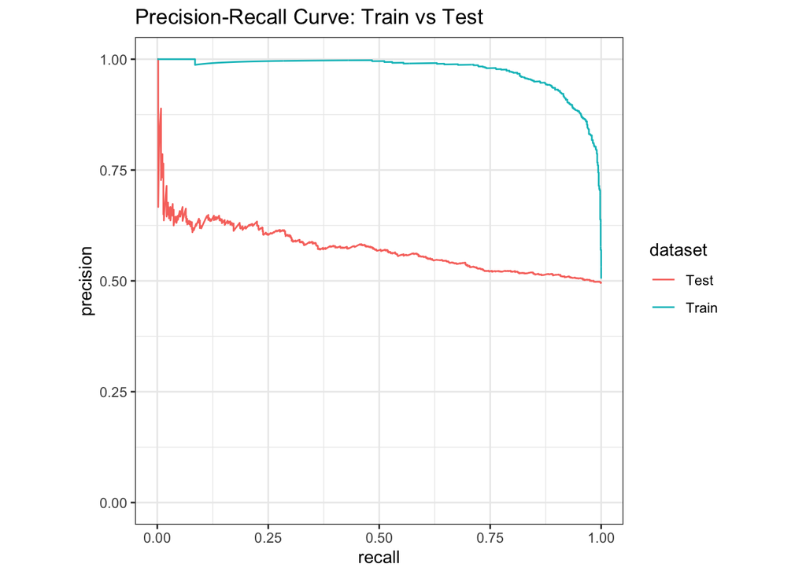

```r
# 6. Plot Precision-Recall Curves
bind_rows(
  train_preds %>% mutate(dataset = "Train"),
  test_preds %>% mutate(dataset = "Test")
) %>%
  group_by(dataset) %>%
  pr_curve(truth = viral, .pred_1) %>%
  autoplot() +
  labs(title = "Precision-Recall Curve: Train vs Test")
```

**Question 2.1:** Compare the performance on Training vs. Test data. Do you notice a large gap? What does this suggest about the model’s ability to generalize to the future?

**Answer:** There is a massive gap between the Train AUC (~0.98) and the Test AUC (~0.58). This indicates severe overfitting. The model essentially memorized specific vocabulary from the older articles in the training set. However, because news trends change over time (Temporal Drift), these words are no longer relevant for the newer articles in the test set. The massive drop in performance shows the model completely fails to generalize to the future.